# Get started

2024-02-21

## 1. Introduction

mimsy is a package designed to calculate dissolved gas concentrations of oxygen, nitrogen, and argon from Membrane Inlet Mass Spectrometer (MIMS) signal data. For more information on the gas solubility equations used in this package, please see the References section. No R expertise is required to use mimsy, and this guide is designed for novice R users.

If you find bugs in this software, or you would like to suggest new features, please let us know on the [mimsy GitHub page](https://github.com/michelleckelly/mimsy/issues).

## 2. Installation

Install mimsy from the CRAN repository and load into your R environment:

```r
# Install the package
install.packages("mimsy")

# Load the package
library(mimsy)
```

Alternatively, the latest in-development version of `mimsy` can be pulled from Github via:

```r
# Install and load devtools
install.packages("devtools")
library(devtools)

# Download mimsy from Github
install_github("michelleckelly/mimsy")

# Load the package
library(mimsy)
```

## 3. Running mimsy

The general structure for running mimsy is:

1. Format your CSV file
2. Load CSV file into R using `read.csv()`
3. Run the `mimsy()` function
4. Explore the results
5. Save the results to an Excel file using `mimsy.save()` or an RData file using `save()`

### 3.1. Format your CSV file

You’ll need to add some special columns to your data file before loading it into R. The easiest way to do this is to use a spreadsheet editor like Excel. We recommend saving a seperate copy of your raw data file for mimsy (add “_mimsy” to the file name) to prevent any accidents.

Click to download an example CSV file for single water bath MIMS setups (“one temperature setups”): Download data_oneTemp.csv

Click to download an example CSV file for dual water bath MIMS setups (“two temperature setups”): Download data_twoTemp.csv

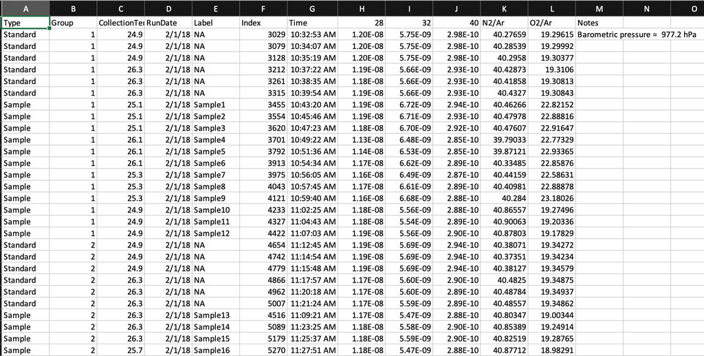

Figure 1. An example of a correctly formatted raw data file for a MIMS setup with two water baths.

**CSV file format:**

- You can save as CSV within Excel from the *File > Save as* menu, choosing the *CSV (Comma delimited) (.csv)* option.

**Columns:**

- Type
  - If the row contains data for a standard, enter “Standard”. If the row contains data for a sample, enter “Sample”.
  - The name of this column must be “Type” (check for correct capitalization)
- Group
  - Each block of standards and the samples run directly afterwards belong to a group. You’ll enter “1” for the first block of standards and the first block of samples. You’ll enter “2” for the second block of standards and the second block of samples, etc.
  - The name of this column must be “Group” (check for correct capitalization)
- CollectionTemp
  - The temperature of samples or standards at the time of field collection, in degrees C
  - The name of this column must be “CollectionTemp” (check for correct capitalization)
- RunDate
  - The date (M/D/YYYY) that samples were run on the MIMS.
  - The name of this column must be “RunDate” (check for correct capitalization)
- Label or other sample identifier columns
  - mimsy will preserve all labelling columns in the final output, so you should add whatever labels or notes columns you like
- Index, Time, 28, 32, 40, N2/Ar, O2/Ar columns
  - This is the default output from the MIMS. If you have a newer setup, this may also include a “99” column indicating the MIMS’ internal pressure. Including, or not including, this column won’t affect your results.

### 3.2. Load your CSV file into R using `read.csv()`

```r
# Load data into R
data <- read.csv(file = "data_twoTemp.csv", header = TRUE, stringsAsFactors = FALSE)

# Check it out
data
```

| Type | Group | CollectionTemp | RunDate | Label | Index | Time | X28 | X32 | X40 | N2.Ar | O2.Ar | Notes |
| --- | --- | --- | --- | --- | --- | --- | --- | --- | --- | --- | --- | --- |
| Standard | 1 | 24.9 | 2/1/18 | NA | 3029 | 10:32:53 AM | 0 | 0 | 0 | 40.27659 | 19.29615 | Barometric pressure = 977.2 hPa |
| Standard | 1 | 24.9 | 2/1/18 | NA | 3079 | 10:34:07 AM | 0 | 0 | 0 | 40.28539 | 19.29992 |  |
| Standard | 1 | 24.9 | 2/1/18 | NA | 3128 | 10:35:19 AM | 0 | 0 | 0 | 40.29580 | 19.30377 |  |
| Standard | 1 | 26.3 | 2/1/18 | NA | 3212 | 10:37:22 AM | 0 | 0 | 0 | 40.42873 | 19.31060 |  |
| Standard | 1 | 26.3 | 2/1/18 | NA | 3261 | 10:38:35 AM | 0 | 0 | 0 | 40.41858 | 19.30813 |  |
| Standard | 1 | 26.3 | 2/1/18 | NA | 3315 | 10:39:54 AM | 0 | 0 | 0 | 40.43270 | 19.30843 |  |
| Sample | 1 | 25.1 | 2/1/18 | Sample1 | 3455 | 10:43:20 AM | 0 | 0 | 0 | 40.46266 | 22.82152 |  |
| Sample | 1 | 25.1 | 2/1/18 | Sample2 | 3554 | 10:45:46 AM | 0 | 0 | 0 | 40.47978 | 22.88816 |  |
| Sample | 1 | 25.1 | 2/1/18 | Sample3 | 3620 | 10:47:23 AM | 0 | 0 | 0 | 40.47607 | 22.91647 |  |
| Sample | 1 | 26.1 | 2/1/18 | Sample4 | 3701 | 10:49:22 AM | 0 | 0 | 0 | 39.79033 | 22.77329 |  |
| Sample | 1 | 26.1 | 2/1/18 | Sample5 | 3792 | 10:51:36 AM | 0 | 0 | 0 | 39.87121 | 22.93365 |  |
| Sample | 1 | 26.1 | 2/1/18 | Sample6 | 3913 | 10:54:34 AM | 0 | 0 | 0 | 40.33485 | 22.85876 |  |
| Sample | 1 | 25.3 | 2/1/18 | Sample7 | 3975 | 10:56:05 AM | 0 | 0 | 0 | 40.44159 | 22.58631 |  |
| Sample | 1 | 25.3 | 2/1/18 | Sample8 | 4043 | 10:57:45 AM | 0 | 0 | 0 | 40.40981 | 22.88878 |  |
| Sample | 1 | 25.3 | 2/1/18 | Sample9 | 4121 | 10:59:40 AM | 0 | 0 | 0 | 40.28400 | 23.18026 |  |
| Sample | 1 | 24.9 | 2/1/18 | Sample10 | 4233 | 11:02:25 AM | 0 | 0 | 0 | 40.86557 | 19.27496 |  |
| Sample | 1 | 24.9 | 2/1/18 | Sample11 | 4327 | 11:04:43 AM | 0 | 0 | 0 | 40.90063 | 19.20336 |  |
| Sample | 1 | 24.9 | 2/1/18 | Sample12 | 4422 | 11:07:03 AM | 0 | 0 | 0 | 40.87803 | 19.17829 |  |
| Standard | 2 | 24.9 | 2/1/18 | NA | 4654 | 11:12:45 AM | 0 | 0 | 0 | 40.38071 | 19.34272 |  |
| Standard | 2 | 24.9 | 2/1/18 | NA | 4742 | 11:14:54 AM | 0 | 0 | 0 | 40.37351 | 19.34234 |  |
| Standard | 2 | 24.9 | 2/1/18 | NA | 4779 | 11:15:48 AM | 0 | 0 | 0 | 40.38127 | 19.34579 |  |
| Standard | 2 | 26.3 | 2/1/18 | NA | 4866 | 11:17:57 AM | 0 | 0 | 0 | 40.48250 | 19.34875 |  |
| Standard | 2 | 26.3 | 2/1/18 | NA | 4962 | 11:20:18 AM | 0 | 0 | 0 | 40.48784 | 19.34937 |  |
| Standard | 2 | 26.3 | 2/1/18 | NA | 5007 | 11:21:24 AM | 0 | 0 | 0 | 40.48557 | 19.34862 |  |
| Sample | 2 | 26.3 | 2/1/18 | Sample13 | 4516 | 11:09:21 AM | 0 | 0 | 0 | 40.80347 | 19.00344 |  |
| Sample | 2 | 26.3 | 2/1/18 | Sample14 | 5089 | 11:23:25 AM | 0 | 0 | 0 | 40.85389 | 19.24914 |  |
| Sample | 2 | 26.3 | 2/1/18 | Sample15 | 5179 | 11:25:37 AM | 0 | 0 | 0 | 40.82519 | 19.28765 |  |
| Sample | 2 | 25.7 | 2/1/18 | Sample16 | 5270 | 11:27:51 AM | 0 | 0 | 0 | 40.87712 | 18.98291 |  |
| Sample | 2 | 25.7 | 2/1/18 | Sample17 | 5370 | 11:30:18 AM | 0 | 0 | 0 | 40.82986 | 19.20466 |  |
| Sample | 2 | 25.7 | 2/1/18 | Sample18 | 5475 | 11:32:53 AM | 0 | 0 | 0 | 40.82610 | 19.27355 |  |
| Sample | 2 | 25.9 | 2/1/18 | Sample19 | 5668 | 11:37:37 AM | 0 | 0 | 0 | 40.29644 | 25.40370 |  |
| Sample | 2 | 25.9 | 2/1/18 | Sample20 | 5741 | 11:39:24 AM | 0 | 0 | 0 | 40.24260 | 25.56124 |  |
| Sample | 2 | 25.9 | 2/1/18 | Sample21 | 5972 | 11:45:04 AM | 0 | 0 | 0 | 40.36147 | 25.51976 |  |
| Sample | 2 | 25.2 | 2/1/18 | Sample22 | 6079 | 11:47:42 AM | 0 | 0 | 0 | 40.03570 | 26.81639 |  |
| Sample | 2 | 25.2 | 2/1/18 | Sample23 | 6192 | 11:50:28 AM | 0 | 0 | 0 | 40.15149 | 26.95080 |  |
| Sample | 2 | 25.2 | 2/1/18 | Sample24 | 6335 | 11:53:58 AM | 0 | 0 | 0 | 39.77960 | 27.15118 |  |
| Standard | 3 | 24.9 | 2/1/18 | NA | 6475 | 11:57:24 AM | 0 | 0 | 0 | 40.46484 | 19.63069 |  |
| Standard | 3 | 24.9 | 2/1/18 | NA | 6542 | 11:59:03 AM | 0 | 0 | 0 | 40.46932 | 19.53179 |  |
| Standard | 3 | 24.9 | 2/1/18 | NA | 6599 | 12:00:27 PM | 0 | 0 | 0 | 40.49352 | 19.50314 |  |
| Standard | 3 | 26.3 | 2/1/18 | NA | 6723 | 12:03:29 PM | 0 | 0 | 0 | 40.55150 | 19.45527 |  |
| Standard | 3 | 26.3 | 2/1/18 | NA | 6825 | 12:05:59 PM | 0 | 0 | 0 | 40.54939 | 19.42995 |  |
| Standard | 3 | 26.3 | 2/1/18 | NA | 6870 | 12:07:06 PM | 0 | 0 | 0 | 40.55973 | 19.42807 |  |

Don’t be worried that your “28”, “32”, and “40” columns are now “X28”, “X32”, and “X40”. As R doesn’t accept column names that start with a number, it added an “X” to these column names when the data was imported. Similarly, “N2/Ar” and “O2/Ar” have been automatically adjusted to “N2.Ar” and “O2.Ar”.

### 3.3. Run the `mimsy()` function

You must specify the barometric pressure (as `baromet.press`) and its units in the function argument. Units must be one of `"atm"`, `"hPa"`, `"psi"`, `"bar"`, or `"Torr"`. All other inputs, such as background corrections or standard salinity, are optional. Check out `?mimsy` for more information.

```r
# Run the function
results <- mimsy(data, baromet.press = 977.2, units = "hPa")
```

```
#> Calculated dissolved concentrations based on a two-point temperature standard.
#> Standard 1: 24.9 C, Standard 2: 26.3 C
```

### 3.4. Explore the results

You’ll see that `mimsy()` returns a list containing five seperate dataframes (`results`, `solubility.Concentrations`, `calibration.Factors`, `calibration.DriftCorrection`, and `results.full`). Check out ?mimsy() for more specific information on those outputs and how they were calculated.

```r
# Check out the summarized results
results$results
```

The summarized results includes the calculated gas concentrations for all samples:

| CollectionTemp | Label | Notes | arSat.conc_uMol.kg | n2Sat.conc_uMol.kg | o2Sat.conc_uMol.kg | Ar_uMolL | N2Ar | O2Ar | N2_uMolL | O2_uMolL | N2_mgL | O2_mgL | Ar_mgL |
| --- | --- | --- | --- | --- | --- | --- | --- | --- | --- | --- | --- | --- | --- |
| 25.1 | Sample1 |  | 12.09965 | 470.8931 | 256.0983 | 11.58375 | 39.04704 | 25.01304 | 472.4557 | 302.6491 | 13.22876 | 9.684772 | 0.4633502 |
| 25.1 | Sample2 |  | 12.09965 | 470.8931 | 256.0983 | 11.55084 | 39.05838 | 25.08267 | 472.5929 | 303.4915 | 13.23260 | 9.711729 | 0.4620337 |
| 25.1 | Sample3 |  | 12.09965 | 470.8931 | 256.0983 | 11.51571 | 39.05136 | 25.11142 | 472.5079 | 303.8394 | 13.23022 | 9.722862 | 0.4606286 |
| 26.1 | Sample4 |  | 11.88145 | 463.3433 | 253.0292 | 11.17233 | 38.37769 | 25.09848 | 455.9827 | 298.2064 | 12.76751 | 9.542604 | 0.4468932 |
| 26.1 | Sample5 |  | 11.88145 | 463.3433 | 253.0292 | 11.18067 | 38.45231 | 25.27225 | 456.8693 | 300.2711 | 12.79234 | 9.608674 | 0.4472269 |
| 26.1 | Sample6 |  | 11.88145 | 463.3433 | 253.0292 | 11.34883 | 38.89491 | 25.18581 | 462.1280 | 299.2440 | 12.93958 | 9.575807 | 0.4539532 |
| 25.3 | Sample7 |  | 12.05545 | 469.3628 | 255.4663 | 11.32820 | 38.99877 | 24.76680 | 470.1476 | 298.5748 | 13.16413 | 9.554393 | 0.4531279 |
| 25.3 | Sample8 |  | 12.05545 | 469.3628 | 255.4663 | 11.41191 | 38.96478 | 25.09616 | 469.7378 | 302.5454 | 13.15266 | 9.681451 | 0.4564764 |
| 25.3 | Sample9 |  | 12.05545 | 469.3628 | 255.4663 | 11.37789 | 38.83963 | 25.41305 | 468.2291 | 306.3657 | 13.11041 | 9.803702 | 0.4551155 |
| 24.9 | Sample10 |  | 12.14415 | 472.4339 | 256.7397 | 11.40900 | 39.39490 | 21.07834 | 478.4175 | 255.9785 | 13.39569 | 8.191311 | 0.4563599 |
| 24.9 | Sample11 |  | 12.14415 | 472.4339 | 256.7397 | 11.45413 | 39.42348 | 20.99730 | 478.7645 | 254.9943 | 13.40541 | 8.159818 | 0.4581651 |
| 24.9 | Sample12 |  | 12.14415 | 472.4339 | 256.7397 | 11.49938 | 39.39640 | 20.96711 | 478.4356 | 254.6277 | 13.39620 | 8.148087 | 0.4599751 |
| 26.3 | Sample13 |  | 11.83865 | 461.8634 | 252.4423 | 11.36148 | 39.32482 | 20.95014 | 465.5527 | 248.0213 | 13.03548 | 7.936681 | 0.4544592 |
| 26.3 | Sample14 |  | 11.83865 | 461.8634 | 252.4423 | 11.47147 | 39.35255 | 21.19046 | 465.8809 | 250.8664 | 13.04467 | 8.027724 | 0.4588589 |
| 26.3 | Sample15 |  | 11.83865 | 461.8634 | 252.4423 | 11.47633 | 39.32164 | 21.22807 | 465.5150 | 251.3116 | 13.03442 | 8.041970 | 0.4590534 |
| 25.7 | Sample16 |  | 11.96789 | 466.3329 | 254.2297 | 11.42968 | 39.36071 | 20.79488 | 471.0646 | 248.8709 | 13.18981 | 7.963867 | 0.4571871 |
| 25.7 | Sample17 |  | 11.96789 | 466.3329 | 254.2297 | 11.43503 | 39.31090 | 21.02942 | 470.4685 | 251.6778 | 13.17312 | 8.053691 | 0.4574012 |
| 25.7 | Sample18 |  | 11.96789 | 466.3329 | 254.2297 | 11.44067 | 39.30274 | 21.09600 | 470.3709 | 252.4746 | 13.17039 | 8.079187 | 0.4576269 |
| 25.9 | Sample19 |  | 11.92453 | 464.8331 | 253.6250 | 11.40212 | 38.78803 | 27.83127 | 462.5291 | 331.8749 | 12.95082 | 10.619997 | 0.4560849 |
| 25.9 | Sample20 |  | 11.92453 | 464.8331 | 253.6250 | 11.40601 | 38.73328 | 27.99674 | 461.8763 | 333.8481 | 12.93254 | 10.683138 | 0.4562404 |
| 25.9 | Sample21 |  | 11.92453 | 464.8331 | 253.6250 | 11.41837 | 38.83837 | 27.92871 | 463.1294 | 333.0369 | 12.96762 | 10.657180 | 0.4567346 |
| 25.2 | Sample22 |  | 12.07751 | 470.1267 | 255.7812 | 11.29627 | 38.50567 | 29.14297 | 465.0527 | 351.9746 | 13.02148 | 11.263187 | 0.4518508 |
| 25.2 | Sample23 |  | 12.07751 | 470.1267 | 255.7812 | 11.34212 | 38.61164 | 29.27172 | 466.3326 | 353.5296 | 13.05731 | 11.312947 | 0.4536849 |
| 25.2 | Sample24 |  | 12.07751 | 470.1267 | 255.7812 | 11.18978 | 38.24725 | 29.46728 | 461.9316 | 355.8915 | 12.93409 | 11.388528 | 0.4475911 |

```r
# Check out the solubility concentrations
results$solubility.Concentrations
```

|  | O2.conc_uMol.kg | N2.conc_uMol.kg | Ar.conc_uMol.kg |
| --- | --- | --- | --- |
| 24.9 deg C | 256.7397 | 472.4339 | 12.14415 |
| 26.3 deg C | 252.4423 | 461.8634 | 11.83865 |

Check out ?mimsy() for more specific information on the `results`, `solubility.Concentrations`, `calibration.Factors`, `calibration.DriftCorrection`, and `results.full` dataframes, including details on how they were calculated.

### 3.5. Save the results

```r
# Save output to an Excel workbook
mimsy.save(results, file = "results.xlsx")

# Save output to an RData file
save(results, file = "results.RData")
```

We don’t reccomend saving results dataframes to CSV files (although it is possible), as you’ll need multiple CSV’s to preserve all of the outputs, and that gets kind of messy. A good alternative is to save both an Excel workbook copy and an RData copy, that way all of your output is preserved every time.

You can load RData files back into R using `load("results.RData")`. Check out `?load()` for more info.

## 4. Putting it all together

```r
# Install mimsy
install.packages("mimsy")

# Load mimsy
library(mimsy)

# Load data into R
data <- read.csv(file = "data.csv", header = TRUE, stringsAsFactors = FALSE)

# Run the mimsy function
results <- mimsy(data, baromet.press = 977.2, units = "hPa")

# Save the results
mimsy.save(results, file = "results.xlsx") # To Excel file
save(results, file = "results.RData") # To RData file

# Done! :)
```